# Coursera Practical Machine Learning Project

Chris Rector

October 22, 2016

# Synopsis

This data analysis was done as the class project for the Johns Hopkins Practical Machine Learning course on Coursera. In this report we analyze data from fitness trackers worn by several participants who performed various excercises. For each excercise a series of measurements were recorded as well as an assessment of whether the individual performed the exercise correctly. This assessment is captured in the “classe” variable in the dataset.

We use this data to build a model that will then be used to make predictions of whether or not an excercise was performed correctly based on the various measurements.

Recognition goes to the researchers that make this data publicly available:

Ugulino, W.; Cardador, D.; Vega, K.; Velloso, E.; Milidiu, R.; Fuks, H. Wearable Computing: Accelerometers’ Data Classification of Body Postures and Movements. Proceedings of 21st Brazilian Symposium on Artificial Intelligence. Advances in Artificial Intelligence - SBIA 2012. In: Lecture Notes in Computer Science. , pp. 52-61. Curitiba, PR: Springer Berlin / Heidelberg, 2012. ISBN 978-3-642-34458-9. DOI: 10.1007/978-3-642-34459-6_6

Read more: http://groupware.les.inf.puc-rio.br/har#sbia_paper_section#ixzz4OVyHB3W4

```r
library(caret)
library(randomForest)
library(rpart)
library(gbm)
library(survival)
library(splines)
library(parallel)
library(plyr)
```

# Data processing

The data comes already split into training and test sets. We decided to take the complete training set and split it into a training and test set to allow us to build and test a model within the supplied training set. We split the complete training set 75%/25% into training and test sets for us to train our model.

With our available hardware we found it impossible to process the data as-is with the large nubmer of variables so we first removed variables that had near-zero variance. We also removed the timestamp variables and the record number (x) as they have no bearing on the test outcome and can confuse our models.

```r
modTreeBoot5 <- train(classe ~., method="rpart", data=x, trControl=trainControl(method = "boot", number = 5))
max(modTreeBoot5$results[,"Accuracy"])
```

```
## [1] 0.4879563
```

```r
modTreeCv5 <- train(classe ~., method="rpart", data=x, trControl=trainControl(method = "cv", number = 5))
max(modTreeCv5$results[,"Accuracy"])
```

```
## [1] 0.5080151
```

```r
modGbmBoot5 <- train(classe ~., method="gbm", data=x, verbose=FALSE,
                    trControl=trainControl(method = "boot", number = 5))
max(modGbmBoot5$results[,"Accuracy"])
```

```
## [1] 0.8561095
```

```r
modForestCv5 <- train(classe ~., method="rf", data=x, verbose=FALSE,
                      trControl=trainControl(method = "cv", number = 5))
max(modForestCv5$results[,"Accuracy"])
```

```
## [1] 0.88
```

```r
cm_modForestCv5 <- confusionMatrix(testing$classe, predict(modForestCv5, testing))
cm_modForestCv5
```

```
## Confusion Matrix and Statistics
##
##           Reference
## Prediction    A    B    C    D    E
##          A 1373    7    6    8    1
##          B   72  826   39   10    2
##          C    3   44  787   19    2
##          D   18    8   40  737    1
##          E    6   84   19   19  773
##
## Overall Statistics
##
##                Accuracy : 0.9168
##                  95% CI : (0.9087, 0.9244)
##     No Information Rate : 0.3002
##     P-Value [Acc > NIR] : < 2.2e-16
##
##                   Kappa : 0.8946
##  Mcnemar's Test P-Value : < 2.2e-16
##
## Statistics by Class:
##
##                      Class: A Class: B Class: C Class: D Class: E
## Sensitivity            0.9327   0.8524   0.8833   0.9294   0.9923
## Specificity            0.9936   0.9687   0.9831   0.9837   0.9690
## Pos Pred Value         0.9842   0.8704   0.9205   0.9167   0.8579
## Neg Pred Value         0.9718   0.9638   0.9743   0.9863   0.9985
## Prevalence             0.3002   0.1976   0.1817   0.1617   0.1588
## Detection Rate         0.2800   0.1684   0.1605   0.1503   0.1576
## Detection Prevalence   0.2845   0.1935   0.1743   0.1639   0.1837
## Balanced Accuracy      0.9632   0.9106   0.9332   0.9565   0.9806
```

# Final Model

We then built our final random forest model on the training set. We used k-fold cross validation with 2 folds as we found any greater number of folds was too demanding for the hardware at our disposal when we used the full training set. Our in-sample accuracy remained greater than 90%.

```r
modFit <- train(classe ~., method="rf", data=training_trim, verbose=FALSE,
                      trControl=trainControl(method = "cv", number = 2))

max(modFit$results[,"Accuracy"])
```

```
## [1] 0.9857996
```

```r
cm_modFit <- confusionMatrix(testing$classe, predict(modFit, testing))
cm_modFit
```

```
## Confusion Matrix and Statistics
##
##           Reference
## Prediction    A    B    C    D    E
##          A 1393    1    0    0    1
##          B    9  937    3    0    0
##          C    0    4  848    3    0
##          D    0    0    8  794    2
##          E    0    0    0    0  901
##
## Overall Statistics
##
##                Accuracy : 0.9937
##                  95% CI : (0.991, 0.9957)
##     No Information Rate : 0.2859
##     P-Value [Acc > NIR] : < 2.2e-16
##
##                   Kappa : 0.992
##  Mcnemar's Test P-Value : NA
##
## Statistics by Class:
##
##                      Class: A Class: B Class: C Class: D Class: E
## Sensitivity            0.9936   0.9947   0.9872   0.9962   0.9967
## Specificity            0.9994   0.9970   0.9983   0.9976   1.0000
## Pos Pred Value         0.9986   0.9874   0.9918   0.9876   1.0000
## Neg Pred Value         0.9974   0.9987   0.9973   0.9993   0.9993
## Prevalence             0.2859   0.1921   0.1752   0.1625   0.1843
## Detection Rate         0.2841   0.1911   0.1729   0.1619   0.1837
## Detection Prevalence   0.2845   0.1935   0.1743   0.1639   0.1837
## Balanced Accuracy      0.9965   0.9958   0.9927   0.9969   0.9983
```

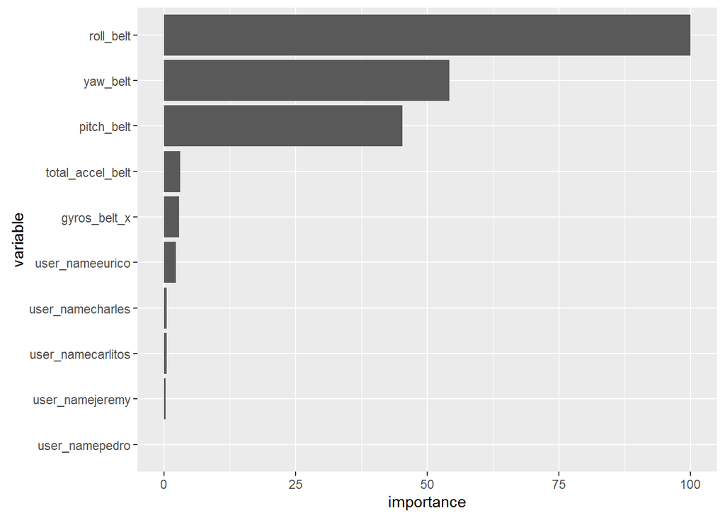

```r
vi_modFit <- varImp(modFit)
#vi_modFit
vi_df <-data.frame(rownames(vi_modFit[1]$importance), vi_modFit[1][1]$importance$Overall)
colnames(vi_df) <- c("variable", "importance")
ggplot(vi_df[1:10,], aes(x=reorder(variable, importance), y=importance)) + geom_bar(stat="identity") + coord_flip() + xlab("variable")
```

Our final model showed an estimated out of sample accuracy of 99%. Given this acceptable accuracy we will proceed to use this model on the final 20-sample testing set.